# Lab 04 / Exam 2 Rough Draft

Hypothesis tests and confidence intervals

Author

## Grading notes

Each part (a,b,c, etc) is worth 0.5 point (15 points total) + 5 points for neatness and organization.

```r
library(tidyverse)
library(infer)

gss2016 <- read_csv("https://docs.google.com/spreadsheets/d/e/2PACX-1vSXStAOCL3Y19OuZAoREVDHKzgiBycVo5h5NRvkU3l4IB81kx-BMU4hurcpWSdfYszJIRQJZ7QblJ8-/pub?output=csv")

beach_vb <- readRDS("beach_vb_lab04.RDS")
```

## Exercise 1

a. The difference in proportions (between women and men who believe in life after death) (OK if they just state the first part)

b. $p_1 - p_2$

c. $\hat{p}_1 - \hat{p}_2$

## Exercise 2

(either of the following sets of hypotheses are correct)

$$H_0: p_1 - p_2 = 0$$
$$H_A: p_1 - p_2 \neq 0$$

$$H_0: p_1 = p_2$$
$$H_A: p_1 \neq p_2$$

## Exercise 3

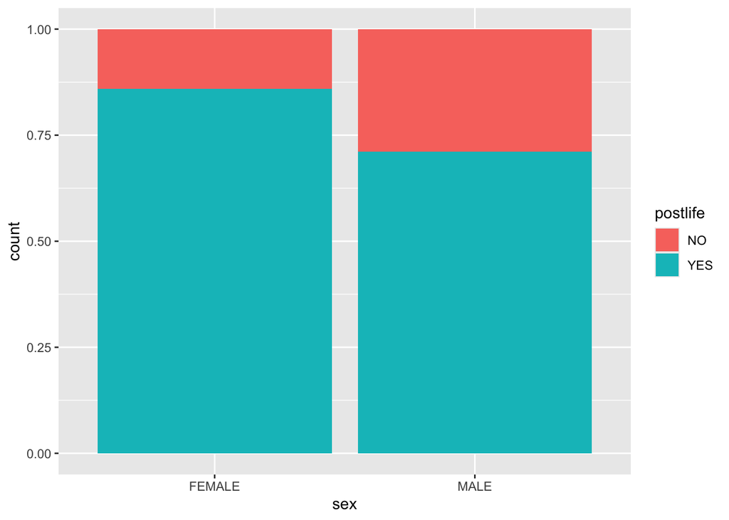

```r
ggplot(data = gss2016, aes(x = sex, fill = postlife)) +
  geom_bar(position = "fill")
```

b. sex

c. postlife

d. you would change “postlife” to “cappun”

## Exercise 4

```r
gss2016 %>%
  group_by(sex) %>%
  summarize(count = sum(postlife == "YES"),
            n = n()) %>%
  mutate(p_hat = count/n)
```

```
# A tibble: 2 × 4
  sex    count     n p_hat
  <chr>  <int> <int> <dbl>
1 FEMALE    73    85 0.859
2 MALE      37    52 0.712
```

b. $\hat{p}_1 - \hat{p}_2 = .859 - .712 = .147$

## Exercise 5

a. Was there random sampling? Are there at least 10 “successes” and 10 “failures” in each group?

b. Yes. The GSS uses a random sample of Americans. And we also have at least 10 success/failures in each group (73 and 12 for females, 37 and 15 for males).

```r
prop_test(gss2016, response = postlife, explanatory = sex,
          success = "YES", z = TRUE)
```

```
# A tibble: 1 × 5
  statistic p_value alternative lower_ci upper_ci
      <dbl>   <dbl> <chr>          <dbl>    <dbl>
1      2.10  0.0355 two.sided    0.00361    0.291
```

d. Z = 2.10

e. p-value = 0.0355

f. The probability of observing a difference in proportions as extreme as 0.147, assuming the null hypothesis is true (there is no true difference), is 0.0355.

g. Our p-value is greater than alpha, so we fail to reject the null hypothesis. There is insufficient evidence to claim men and women believe in the afterlife at different rates.

## Exercise 6

```r
prop_test(gss2016, response = postlife,
          explanatory = sex, success = "YES",
          z = TRUE, conf_level = 0.99)
```

```
# A tibble: 1 × 5
  statistic p_value alternative lower_ci upper_ci
      <dbl>   <dbl> <chr>          <dbl>    <dbl>
1      2.10  0.0355 two.sided    -0.0415    0.336
```

b. We are 99% confident that the true difference in proportions between females and males who believe in the afterlife is between -0.0415 and 0.336.

c. Because the null value (0) is contained in the interval, we fail to reject the null hypothesis (this agrees with the decision based off of the p-value).

## Exercise 7

a.
$$H_0: \mu_1 = \mu_2 \text{ OR } \mu_1 - \mu_2 = 0$$
$$H_A: \mu_1 \neq \mu_2 \text{ OR } \mu_1 - \mu_2 \neq 0$$

b. Difference in means, $\mu_1 - \mu_2$

c. $\bar{x}_1 - \bar{x}_2$

## Exercise 8

```r
beach_vb %>%
  group_by(gender) %>%
  summarize(mean_age = mean(player_age, na.rm = TRUE))
```

```
# A tibble: 2 × 2
  gender mean_age
  <chr>     <dbl>
1 M          29.0
2 W          27.7
```

b. $\bar{x}_1 - \bar{x}_2 = 29.0 - 27.7 = 1.3$

c. you should change `player_age` to `player_height`, and update the summary statistic label to be `mean_height` instead of `mean_age`

## Exercise 9

```r
t_test(beach_vb, response = player_age, explanatory = gender,
       conf_level = 0.99)
```

```
# A tibble: 1 × 7
  statistic  t_df  p_value alternative estimate lower_ci upper_ci
      <dbl> <dbl>    <dbl> <chr>          <dbl>    <dbl>    <dbl>
1      6.73 3516. 1.92e-11 two.sided       1.31    0.811     1.82
```

b. We can reject the null hypothesis because our p-value (1.92e-11) is very very small, and definitely less than alpha (0.01). This means there is sufficient evidence to claim the average age of beach volleyball players differs by gender.

c. We are 99% confident that the true difference in average age of beach volleyball players between men and women is between 0.811 and 1.82 years (men tend to be older).

d. The null value (0) is not in the confidence interval, so we can reject H0.